# Chapter 6

# RATS datas

**Importing libraries**

```r
library(dplyr)
library(tidyr)
library(lme4)
```

```r
library(ggplot2)
```

**Looking at data of RATS**

```r
glimpse(RATSL)
```

```
## Rows: 176
## Columns: 5
## $ ID     <fct> 1, 2, 3, 4, 5, 6, 7, 8, 9, 10, 11, 12, 13, 14, 15, 16, 1, 2,...
## $ Group  <fct> 1, 1, 1, 1, 1, 1, 1, 1, 2, 2, 2, 2, 3, 3, 3, 3, 1, 1, 1, 1, ...
## $ WD     <chr> "WD1", "WD1", "WD1", "WD1", "WD1", "WD1", "WD1", "WD1", "WD1...
## $ Weight <int> 240, 225, 245, 260, 255, 260, 275, 245, 410, 405, 445, 555, ...
## $ Time   <int> 1, 1, 1, 1, 1, 1, 1, 1, 1, 1, 1, 1, 1, 1, 1, 1, 8, 8, 8, 8, ...
```

As we can see, the RATS data has 176 rows and 5 columns. If we look at the data sources, we can see that there are 16 rats and three groups. Eight rats are in group one, four rats are in group 2, and the last four are in group 3.

**Visualizating the data**

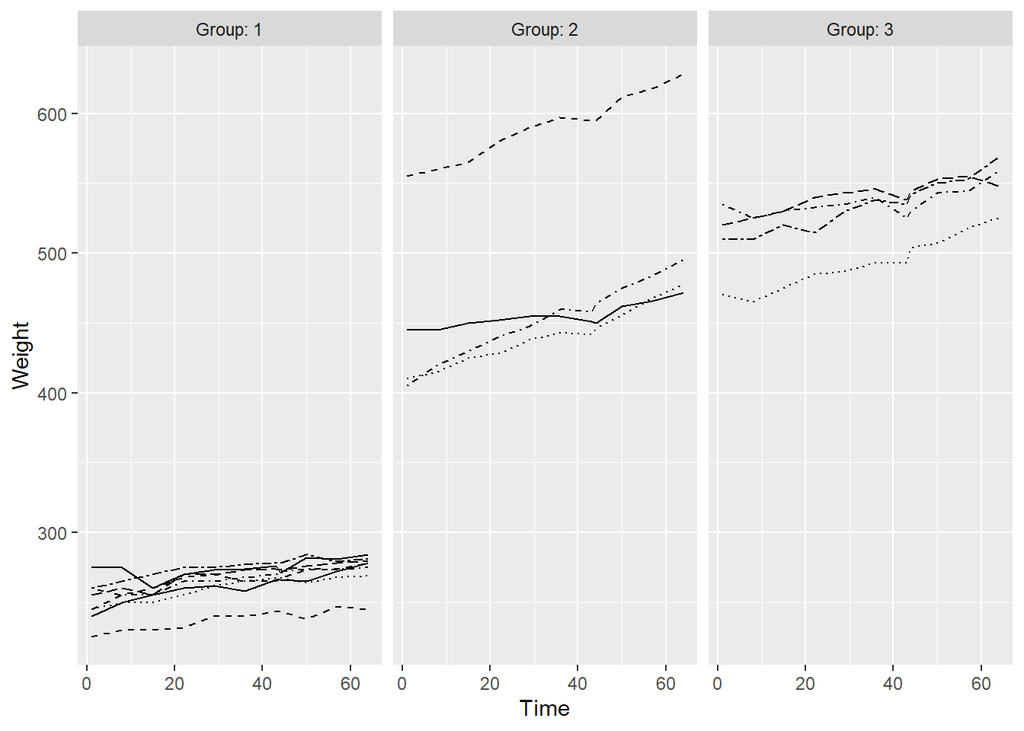

```r
ggplot(RATSL, aes(x = Time, y = Weight, linetype = ID)) +
  geom_line() +
  scale_linetype_manual(values = rep(1:10, times=4)) +
  facet_grid(. ~ Group, labeller = label_both) +
  theme(legend.position = "none") +
  scale_y_continuous(limits = c(min(RATSL$Weight), max(RATSL$Weight)))
```

If we look at the plot, we can see that the rats from group 1 weight the least, but the other groups have increased weight, but we need to remember that groups two and three weighted more in the beginning of the tests.

**Standardizing weights and visualizating new plot**

```r
RATSL <- RATSL %>%
  group_by(Group) %>%
  mutate(stdweight=scale(Weight) ) %>%
  ungroup()

glimpse(RATSL)
```

[output not shown]

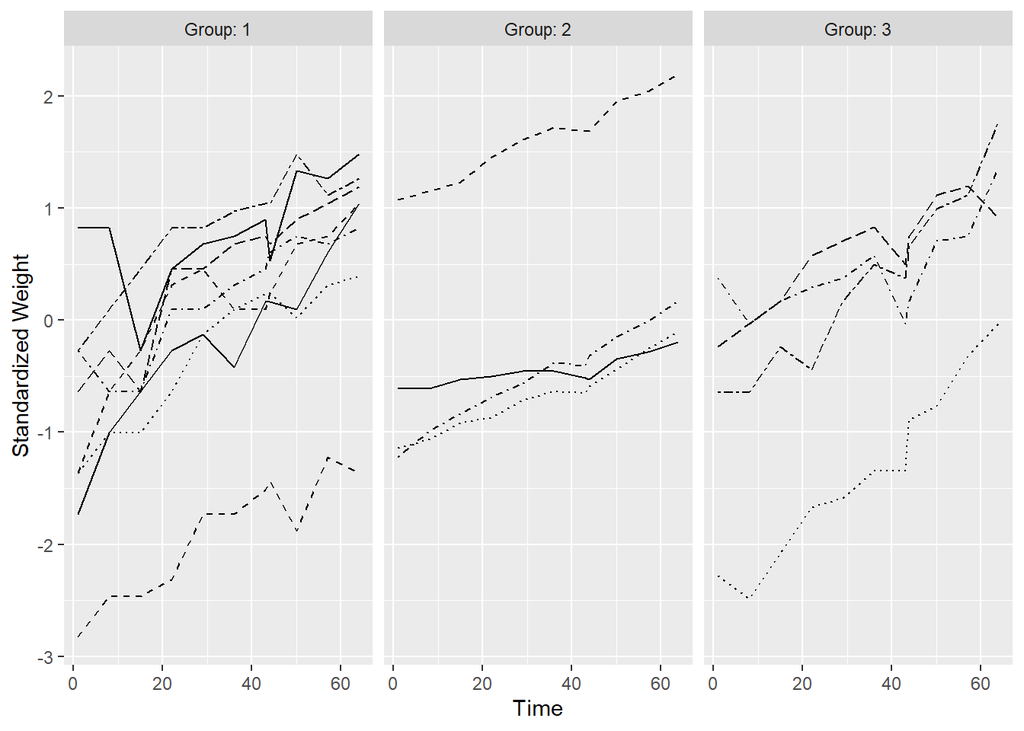

```r
# Plot the data
ggplot(RATSL, aes(x = Time, y = stdweight, linetype = ID)) +
  geom_line() +
  scale_linetype_manual(values = rep(1:10, times=4)) +
  facet_grid(. ~ Group, labeller = label_both) +
  scale_y_continuous(name = "Standardized Weight") +
  theme(legend.position = "none")
```

# BPRS data

The BPRS data contains a study that has 40 subjects in two different groups with “Brief Psychiatric Rating Scale” aka BPRS.

**Looking at the data:**

```r
glimpse(BPRSL)
```

```
## Rows: 360
## Columns: 5
## $ treatment <fct> 1, 1, 1, 1, 1, 1, 1, 1, 1, 1, 1, 1, 1, 1, 1, 1, 1, 1, 1, ...
## $ subject   <fct> 1, 2, 3, 4, 5, 6, 7, 8, 9, 10, 11, 12, 13, 14, 15, 16, 17...
## $ weeks     <chr> "week0", "week0", "week0", "week0", "week0", "week0", "we...
## $ bprs      <int> 42, 58, 54, 55, 72, 48, 71, 30, 41, 57, 30, 55, 36, 38, 6...
## $ week      <int> 0, 0, 0, 0, 0, 0, 0, 0, 0, 0, 0, 0, 0, 0, 0, 0, 0, 0, 0, ...
```

**Visualizating the data**

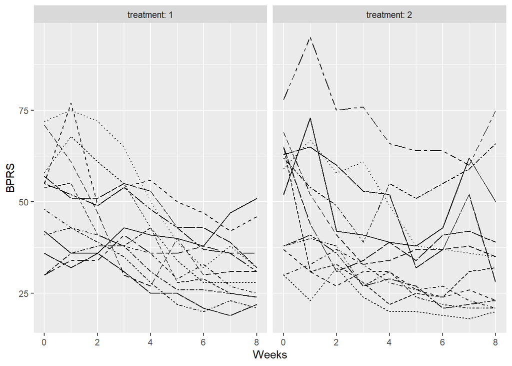

```r
ggplot(BPRSL, aes(x = week, y = bprs, group = subject)) +
  geom_line(aes(linetype=subject)) + facet_grid(. ~ treatment, labeller = label_both) +
  scale_x_continuous(name= "Weeks") + scale_y_continuous(name = "BPRS") + theme(legend.position = "top") +
  theme(legend.position = "none")
```

**Fitting the data to two models**

```r
model1 <- lmer(bprs ~ week + treatment + (weeks | subject), data = BPRSL)
```

```
## boundary (singular) fit: see ?isSingular
```

```r
model2 <- lmer(bprs ~ week * treatment + (weeks | subject), data = BPRSL)
```

```
## boundary (singular) fit: see ?isSingular
```

```r
summary(model1)
```

```
## Linear mixed model fit by REML ['lmerMod']
## Formula: bprs ~ week + treatment + (weeks | subject)
##    Data: BPRSL
##
## REML criterion at convergence: 2720.5
##
## Scaled residuals:
##     Min      1Q  Median      3Q     Max
## -2.8750 -0.5665 -0.0880  0.5723  3.3855
##
## Random effects:
##  Groups   Name        Variance Std.Dev. Corr
##  subject  (Intercept) 69.49    8.336
##           weeksweek1  12.05    3.472     0.26
##           weeksweek2  13.39    3.659    -0.22  0.63
##           weeksweek3  22.84    4.779    -0.27  0.83  0.89
##           weeksweek4  35.24    5.936    -0.59  0.61  0.58  0.85
##           weeksweek5  44.38    6.662    -0.72  0.41  0.38  0.69  0.97
##           weeksweek6  56.45    7.513    -0.64  0.45  0.32  0.67  0.96  0.99
##           weeksweek7  55.05    7.419    -0.44  0.57  0.23  0.64  0.91  0.93
##           weeksweek8  56.12    7.491    -0.32  0.65  0.24  0.66  0.89  0.88
##  Residual             93.17    9.652
##
##
##
##
##
##
##
##
##   0.97
##   0.93  0.99
##
## Number of obs: 360, groups:  subject, 20
##
## Fixed effects:
##             Estimate Std. Error t value
## (Intercept)  44.0875     1.9989  22.055
## week         -2.1522     0.2958  -7.275
## treatment2    0.5722     1.0174   0.562
##
## Correlation of Fixed Effects:
##            (Intr) week
## week       -0.578
## treatment2 -0.254  0.000
## optimizer (nloptwrap) convergence code: 0 (OK)
## boundary (singular) fit: see ?isSingular
```

```r
summary(model2)
```

```
## Linear mixed model fit by REML ['lmerMod']
## Formula: bprs ~ week * treatment + (weeks | subject)
##    Data: BPRSL
##
## REML criterion at convergence: 2717.2
##
## Scaled residuals:
##     Min      1Q  Median      3Q     Max
## -2.9990 -0.5893 -0.0968  0.5262  3.5095
##
## Random effects:
##  Groups   Name        Variance Std.Dev. Corr
##  subject  (Intercept) 69.91    8.361
##           weeksweek1  12.17    3.488     0.25
##           weeksweek2  13.73    3.706    -0.22  0.64
##           weeksweek3  23.33    4.830    -0.27  0.83  0.89
##           weeksweek4  35.73    5.977    -0.59  0.61  0.58  0.85
##           weeksweek5  44.85    6.697    -0.72  0.41  0.39  0.69  0.97
##           weeksweek6  56.96    7.547    -0.64  0.46  0.33  0.67  0.96  0.99
##           weeksweek7  55.42    7.444    -0.44  0.57  0.23  0.64  0.91  0.93
##           weeksweek8  56.48    7.515    -0.32  0.65  0.24  0.66  0.89  0.88
##  Residual             92.44    9.614
##
##
##
##
##
##
##
##
##   0.97
##   0.93  0.99
##
## Number of obs: 360, groups:  subject, 20
##
## Fixed effects:
##                 Estimate Std. Error t value
## (Intercept)      45.4954     2.1453  21.207
## week             -2.5082     0.3548  -7.069
## treatment2       -2.2911     1.8687  -1.226
## week:treatment2   0.7158     0.3925   1.824
##
## Correlation of Fixed Effects:
##             (Intr) week   trtmn2
## week        -0.650
## treatment2  -0.436  0.465
## wek:trtmnt2  0.366 -0.553 -0.840
## optimizer (nloptwrap) convergence code: 0 (OK)
## boundary (singular) fit: see ?isSingular
```

**Comparing the two fitted models**

```r
anova(model1, model2)
```

```
## refitting model(s) with ML (instead of REML)
```

```
## Data: BPRSL
## Models:
## model1: bprs ~ week + treatment + (weeks | subject)
## model2: bprs ~ week * treatment + (weeks | subject)
##        npar    AIC    BIC  logLik deviance  Chisq Df Pr(>Chisq)
## model1   49 2822.4 3012.8 -1362.2   2724.4
## model2   50 2821.1 3015.4 -1360.5   2721.1 3.3344  1    0.06785 .
## ---
## Signif. codes:  0 '***' 0.001 '**' 0.01 '*' 0.05 '.' 0.1 ' ' 1
```

By looking at the models, according to anova models we can see that there is practically no significant differences between the two treatment groups.